# part1

dogvile

Sep 25, 2015

### Overview:

In this project you will investigate the exponential distribution in R and compare it with the Central Limit Theorem. The exponential distribution can be simulated in R with function rexp(n, lambda) where lambda is the rate parameter. The mean of exponential distribution is 1/lamda and the standard deviation is also 1/lambda. For current purposes the lambda is 0.2 for all of the simulations.

> Illustrate via simulation and associated explanatory text the properties of the distribution of the mean of 40 exponentials. You should:  
> 1. Show the sample mean and compare it to the theoretical mean of the distribution.  
> 2. Show how variable the sample is (via variance) and compare it to the theoretical variance of the distribution.  
> 3. Show that the distribution is approximately normal.

### Simulations:

The simulation can be built in R using the `rexp(n,l)` function, where `n` is the number of exponentials per set, and `l`, or lamda is the rate (a constant that for these purposes is 0.2). We store the matrix with the simulated points(given num,samle,rate and type of distribution) in a variable ‘simulation’

### Sample Mean versus Theoretical Mean:

```r
row_means <- rowMeans(simulation)
sample_mean <- mean(row_means)
theoritical_mean <- 1/lamda
```

[figure not shown]

### Sample Variance versus Theoretical Variance:

```r
theoretical_variance<- (1/lamda)^2/num;# theoretical variance
sample_variance <- var(row_means)      #variance of simulated observations
```

[output not shown]

### Distribution:

As indicator of distribution we will use q-q plot which shows a normal distribution(points across the line)

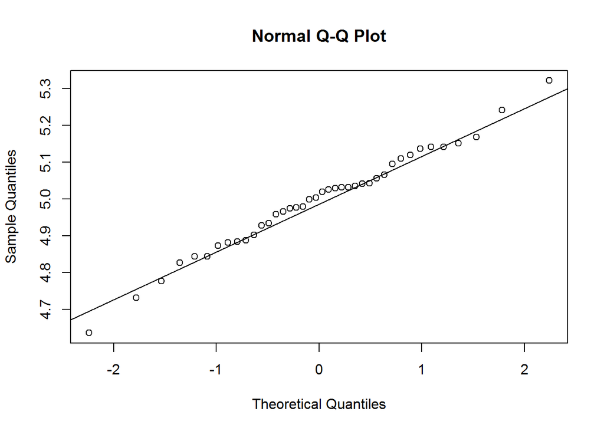

```r
qqnorm(row_means); qqline(row_means)
```